# Business Forecasting for fish production in United States

Vallabh Sawant, Gaurav Vishwakarma, Rakshit Karkera

```r
rm(list = ls())
library(fpp)
library(readxl)
library(TTR)
library(xts)
```

```r
FP_US <- read_excel("Fish_Production_UnitedStates.xlsx")
head(FP_US)
```

| Entity | Code | Year | Capture fisheries production (metric tons) |
| --- | --- | --- | --- |
| United States | USA | 1960 | 2714623 |
| United States | USA | 1961 | 2852004 |
| United States | USA | 1962 | 2897963 |
| United States | USA | 1963 | 2655052 |
| United States | USA | 1964 | 2519951 |
| United States | USA | 1965 | 2649980 |

```r
summary(FP_US)
```

```
    Entity              Code                Year      Capture fisheries production (metric tons)
 Length:57          Length:57          Min.   :1960   Min.   :2311726
 Class :character   Class :character   1st Qu.:1974   1st Qu.:2885967
 Mode  :character   Mode  :character   Median :1988   Median :4721775
                                       Mean   :1988   Mean   :4171508
                                       3rd Qu.:2002   3rd Qu.:5045443
                                       Max.   :2016   Max.   :5694242
```

```r
FP_US_TS <- ts(FP_US$`Capture fisheries production (metric tons)`, start = c(1960))
#FP_US_TS
#class(FP_US_TS)
summary(FP_US_TS)
```

```
   Min. 1st Qu.  Median    Mean 3rd Qu.    Max.
2311726 2885967 4721775 4171508 5045443 5694242
```

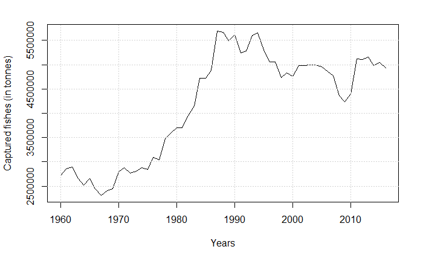

```r
plot(FP_US_TS, xlab = "Years", ylab = "Captured fishes (in tonnes)")
grid(nx=NULL, ny=NULL)
```

# In the above plot, we can see a sudden rise and the data then gets stable after 1988. Thus we can ignore the previous years and consider the data form 1988 for our forecast.

```r
FP_US_TS_recent = window(FP_US_TS,start = c(1988))
summary(FP_US_TS_recent)
```

```
   Min. 1st Qu.  Median    Mean 3rd Qu.    Max.
4233804 4858805 4995418 5040506 5244569 5670666
```

```r
plot(FP_US_TS, xlab = "Years", ylab = "Captured fishes (in tonnes)", main = "Complete data Time series")
grid(nx=NULL, ny=NULL)
```

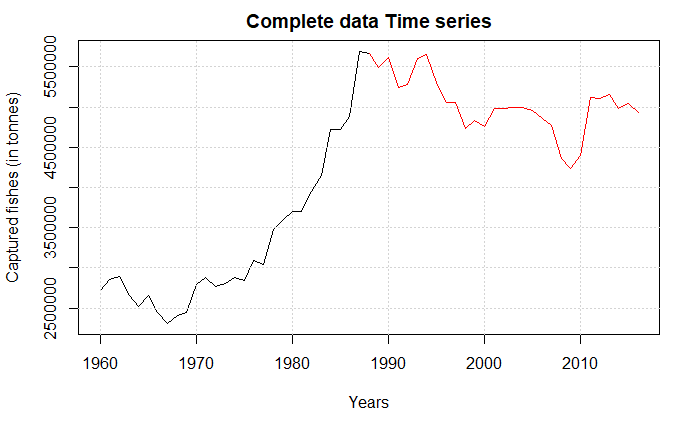

```r
lines(FP_US_TS_recent, col = "Red")
```

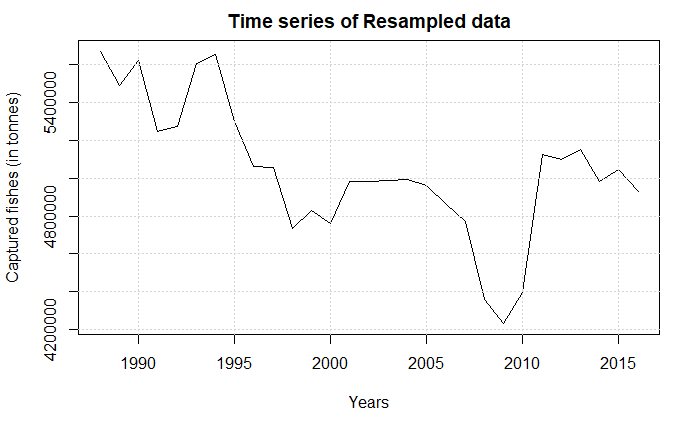

```r
plot(FP_US_TS_recent, xlab = "Years", ylab = "Captured fishes (in tonnes)", main = "Time series of Resampled data")
grid(nx=NULL, ny=NULL)
```

# Looking at the plot, we can come to a conclusion that the data shows no seasonality. It does show some trend.

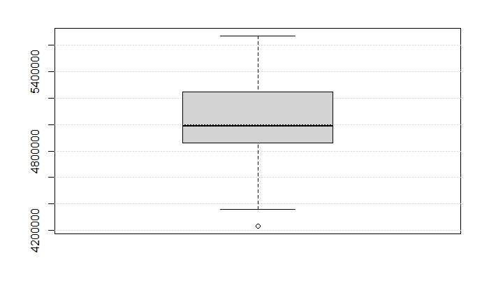

```r
boxplot(FP_US_TS_recent)
grid(nx=NA, ny=NULL)
```

# As stated in the summary, the boxplot confirms the mean is around 5000000 with an outlier. The 1st quartile is 4858805 where as 3rd quartile is at 5244569. The median is at 4995418 and the mean is 5040506.

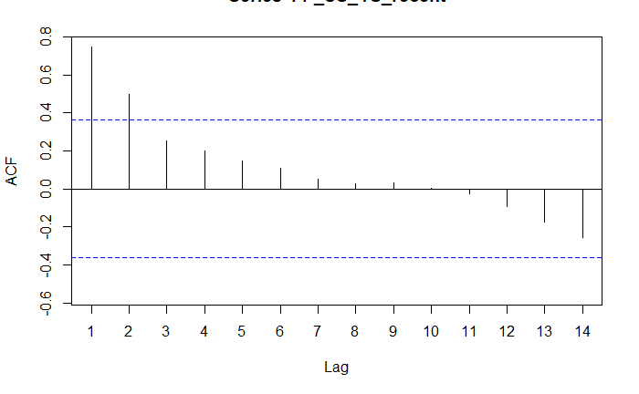

```r
Acf(FP_US_TS_recent)
```

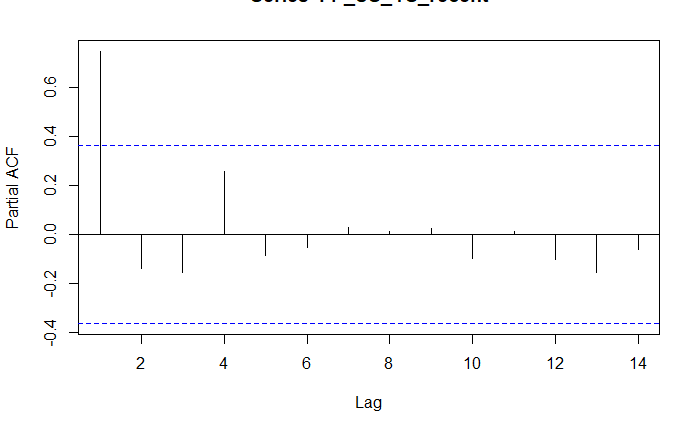

```r
pacf(FP_US_TS_recent)
```

```r
attributes(FP_US_TS_recent)
```

```
$tsp
[1] 1988 2016    1

$class
[1] "ts"
```

# Acf shows a correlation which states the values are highly dependent on the previous values.

# Working on Models

#Naive start

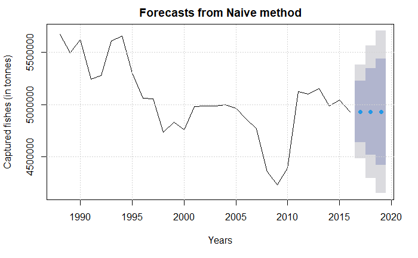

```r
naive_forecast = naive(FP_US_TS_recent,3)
plot(naive_forecast, xlab = "Years", ylab = "Captured fishes (in tonnes)")
grid(nx=NULL, ny=NULL)
```

```r
attributes(naive_forecast)
```

```
$names
 [1] "method"    "model"     "lambda"    "x"         "fitted"    "residuals" "series"    "mean"
 [9] "level"     "lower"     "upper"

$class
[1] "forecast"
```

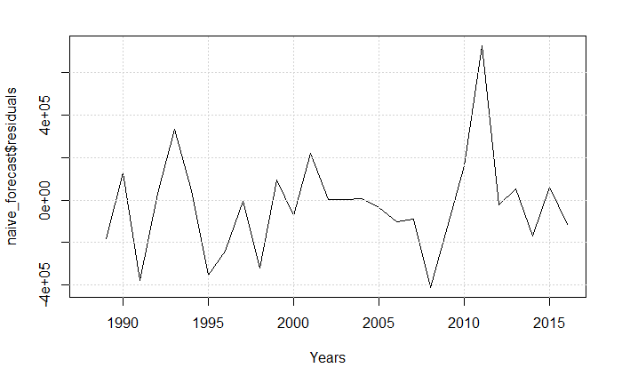

```r
plot(naive_forecast$residuals, xlab = "Years")
grid(nx=NULL, ny=NULL)
```

# Here we don’t see a pattern in the graph. This is a good sign. The residuals are scattered randomly.

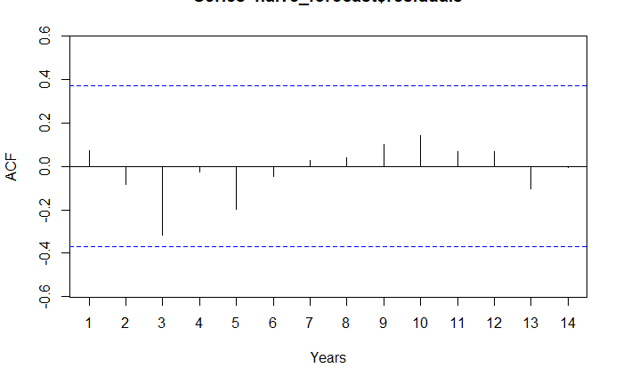

```r
Acf(naive_forecast$residuals, xlab = "Years")
```

# Acf shows no correlation between the residuals. This is ideal.

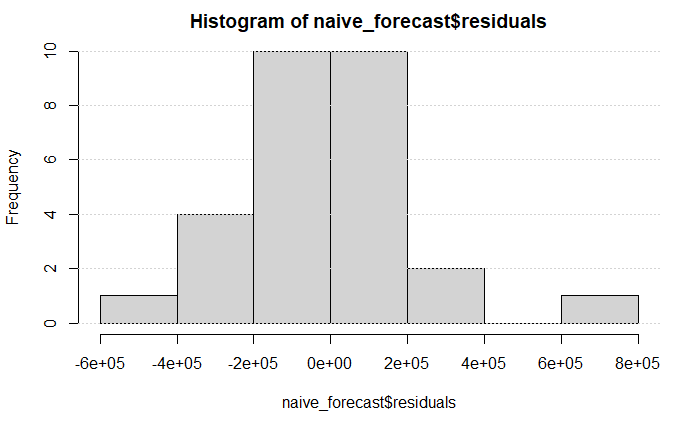

```r
hist(naive_forecast$residuals)
grid(nx=NA, ny=NULL)
```

# The residuals seem a bit right skewed. The histogram also tells us that most of the residuals are on the left side of the mean.

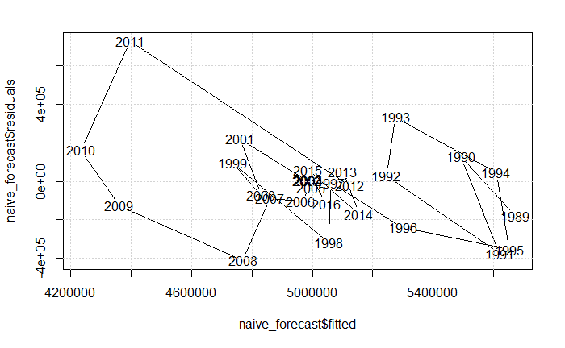

```r
plot(naive_forecast$fitted,naive_forecast$residuals)
grid(nx=NULL, ny=NULL)
```

```
    Ljung-Box test

data:  Residuals from Naive method
Q* = 5.3312, df = 6, p-value = 0.5021

Model df: 0.   Total lags used: 6
```

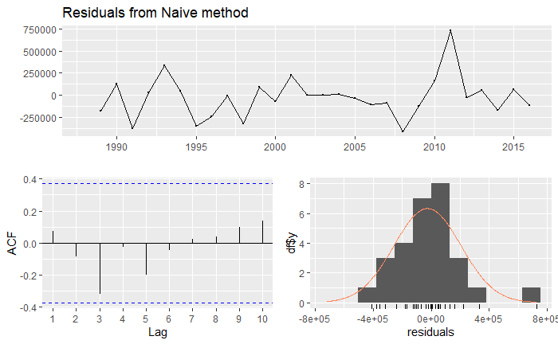

```r
checkresiduals(naive_forecast)
```

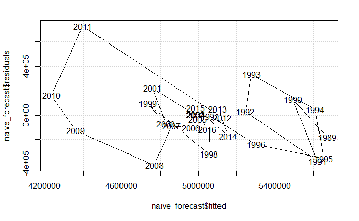

```r
plot(naive_forecast$fitted,naive_forecast$residuals)
grid(nx=NULL, ny=NULL)
```

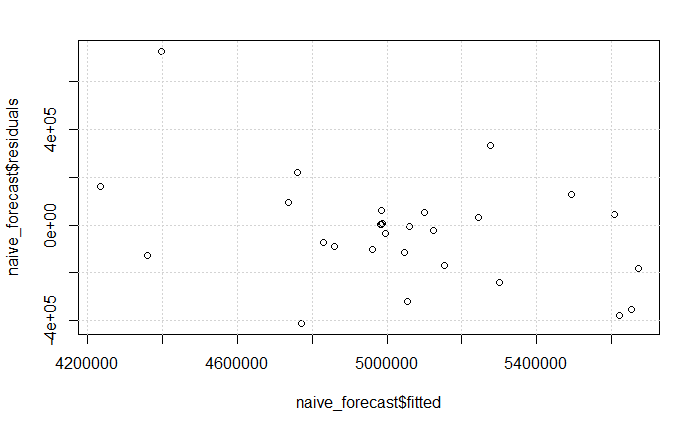

```r
plot.ts(naive_forecast$fitted,naive_forecast$residuals,xy.labels = FALSE,xy.lines = FALSE)
grid(nx=NULL, ny=NULL)
```

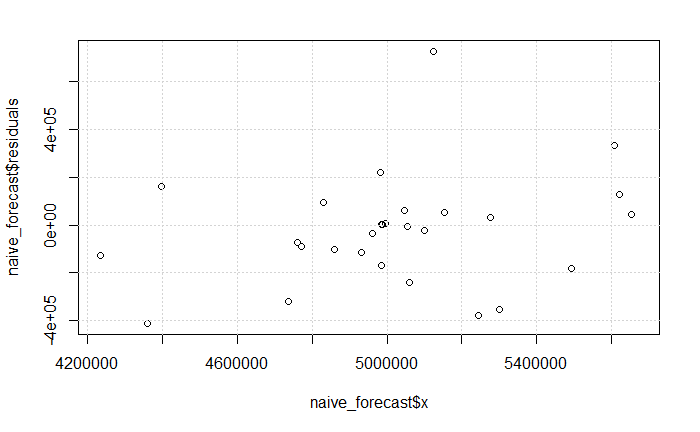

```r
plot.ts(naive_forecast$x,naive_forecast$residuals,xy.labels = FALSE,xy.lines = FALSE)
grid(nx=NULL, ny=NULL)
```